# Acerca del blog

Este es un blog hecho con el paquete [**blogdown**](https://github.com/rstudio/blogdown) en RStudio. El tema utilizado es una adaptación de `hugo-lithium`, que se puede encontrar en el repositorio de [Yihui Xie](https://github.com/yihui/hugo-lithium).

## ¿Qué es blogdown?

Es un paquete para R desarrollado por el equipo de [RStudio](https://rstudio.com/about/) que tiene la finalidad de potenciar el uso de [Rmarkdown](https://rmarkdown.rstudio.com/) para la producción de páginas web estáticas.

## ¿Qué es Rmarkdown?

Es un paquete para R que potencia las funciones de Markdown. Markdown es un lenguaje/herramienta que facilita la edición de textos para publicación web. En la actualidad es ampliamente utilizado en diferentes tipos de plataformas debido a la sencillez de su uso. La traducción al castellano de *R for Data Science* incluye un [sub capítulo](https://es.r4ds.hadley.nz/r-markdown.html#formateo-de-texto-con-markdown) con explicaciones básicas.

Markdown facilita insertar bloques de código en nuestro texto web respetando la sintaxis del lenguaje en el que se escribe.

```r
# Este es un bloque de código R
ggplot(data = iris,
       mapping = aes(
         x = Sepal.Length,
         y = Petal.Length,
         color = Species))+
  geom_jitter()+
  ggtitle(label = "Gráfico de output")
```

Sin embargo, usando Rmarkdown podemos lograr que ese código sea ejecutado y que su output sea incluído automáticamente en el documento web.

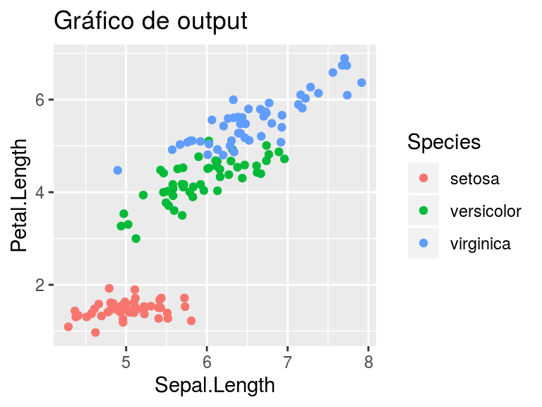

```r
# Este es un bloque de código R
ggplot(data = iris,
       mapping = aes(
         x = Sepal.Length,
         y = Petal.Length,
         color = Species))+
  geom_jitter()+
  ggtitle(label = "Gráfico de output")
```